# Revised Paper Models II

*Simon Yamawaki Shachter*

*September 29, 2018*

```r
dat <- read_rds( "Data_for_Final_Models_Simon.rds" )

# Assign Israel grants to their own grant region
dat$GRANT_REGION_IMPUTED <- as.character( dat$GRANT_REGION_IMPUTED )
dat$GRANT_REGION_IMPUTED[ dat$GRANT_COUNTRY == "Israel" ] <- "Israel"
dat$GRANT_REGION_IMPUTED <- as.character( dat$GRANT_REGION_IMPUTED )

d3 <- dat[ c( "RECIPIENT_KEY", "GM_KEY", "YR_ISSUED", "GRANT_COUNTRY",
              "GRANT_REGION" ) ]
d3$GRANT_REGION <- as.character( dat$GRANT_REGION_IMPUTED )
d3$GRANT_REGION[ d3$GRANT_REGION == "Global" ]  <- "Multiple"
d3$GRANT_REGION[ d3$GRANT_REGION == "Developing" ]  <- "Multiple"

F_REGION_EXPERIENCE <- NULL
F_COUNTRY_EXPERIENCE <- NULL

for( i in 1:nrow( d3 ) ) {
  if( is.na( d3$GRANT_REGION[ i ] ) ) {
    F_REGION_EXPERIENCE[ i ] <- NA
  }
  else {
    year.of.grant <- d3$YR_ISSUED[ i ]
    experience.window <- ( year.of.grant - 3 ):year.of.grant
    these <- d3$GRANT_REGION == d3$GRANT_REGION[ i ] &
      d3$GM_KEY == d3$GM_KEY[ i ] &
      d3$YR_ISSUED %in% experience.window
    F_REGION_EXPERIENCE[ i ] <- sum( these, na.rm = T ) - 1  # don't count current grant
  }
  if( is.na( d3$GRANT_COUNTRY[ i ] ) ) {
    F_COUNTRY_EXPERIENCE[ i ] <- NA
  }
  else {
    year.of.grant <- d3$YR_ISSUED[ i ]
    experience.window <- ( year.of.grant - 3 ):year.of.grant
    these <- d3$GRANT_COUNTRY == d3$GRANT_COUNTRY[ i ] &
      d3$GM_KEY == d3$GM_KEY[ i ] &
      d3$YR_ISSUED %in% experience.window
    F_COUNTRY_EXPERIENCE[ i ] <- sum( these, na.rm = T ) - 1  # don't count current grant
  }
}

dat$F_REGION_EXPERIENCE <- F_REGION_EXPERIENCE
dat$F_COUNTRY_EXPERIENCE <- F_COUNTRY_EXPERIENCE

summary( dat$F_REGION_EXPERIENCE )
summary( dat$F_COUNTRY_EXPERIENCE )
cor( dat$F_REGION_EXPERIENCE, dat$F_COUNTRY_EXPERIENCE, use = "na.or.complete" )

write_rds( dat, "Data_for_Final_Models_Simon_II.rds" )
```

# LOAD DATA

```r
dat <- read_rds( "Data_for_Final_Models_Simon_II.rds" )

# only use post 2004 data so that foundation experience status makes sense

d.baseline <- dat[ dat$YR_ISSUED <= 2004, ]

dat <- dat[ dat$YR_ISSUED > 2004, ]

nrow(dat) # = 106,986
```

```
## [1] 106986
```

```r
# drop foundations with less than 10 grants in database

length( unique( dat$GM_KEY)  ) # 1259
```

```
## [1] 1259
```

```r
t1 <- table( dat$GM_KEY )
t2 <- t1[ t1 > 9 ]
keep.these <- names( t2 )
dat <- dat[ dat$GM_KEY %in% keep.these , ]
dat$GM_KEY <- factor( dat$GM_KEY )

nrow( dat ) # 104,834 only losing 2,152 observations with 899 foundations
```

```
## [1] 104834
```

```r
length( unique( dat$GM_KEY ))  # 693
```

```
## [1] 693
```

```r
# reorder levels
dat$STATUS <- factor( dat$STATUS, levels=c("RENEW","PIONEER","SETTLER") )

# Remove Japan, Korea, New Zealand, and Australia

dat <- dat[ dat$GRANT_COUNTRY != "Japan" | is.na( dat$GRANT_COUNTRY ), ]
nrow( dat ) # 104,343 - lost 491
```

```
## [1] 104343
```

```r
dat <- dat[ dat$GRANT_COUNTRY != "South Korea" | is.na( dat$GRANT_COUNTRY ), ]
nrow( dat ) # 104,218 - lost 125
```

```
## [1] 104218
```

```r
dat <- dat[ dat$GRANT_COUNTRY != "Australia" | is.na( dat$GRANT_COUNTRY ), ]
nrow( dat ) # 104,033 - lost 185
```

```
## [1] 104033
```

```r
dat <- dat[ dat$GRANT_COUNTRY != "New Zealand" | is.na( dat$GRANT_COUNTRY ), ]
nrow( dat ) # 103,997 - lost 36
```

```
## [1] 103997
```

```r
# To impute the grant region, we at least have NGO Region data
dat <- dat[ !is.na( dat$GRANT_REGION_IMPUTED ) &
              !is.na( dat$NGO_REGION ), ]
nrow( dat ) # 95,506 - lost 8,491
```

```
## [1] 95506
```

After adding Israel as a region category, we can see what the regions look like numerically and what the countries in the middle east look like:

```r
dat %>%
  group_by( GRANT_REGION_IMPUTED ) %>%
  summarize( n = n() ) %>%
  arrange( -n ) %>%
  kable()
```

| GRANT_REGION_IMPUTED | n |
| --- | --- |
| Global | 27810 |
| Asia | 14795 |
| Africa | 13584 |
| Latin America | 13345 |
| Developing | 6466 |
| Israel | 5861 |
| Europe | 4710 |
| Former USSR | 3753 |
| Middle East | 3272 |
| Northern America | 1910 |

```r
dat %>%
  filter( GRANT_REGION_IMPUTED == "Middle East" ) %>%
  group_by( GRANT_COUNTRY ) %>%
  summarize( n = n(),
             percentage = n / nrow( filter( dat,
                                            GRANT_REGION_IMPUTED ==
                                              "Middle East" ) ) ) %>%
  arrange( -n ) %>%
  kable( digits = 2 )
```

| GRANT_COUNTRY | n | percentage |
| --- | --- | --- |
| NA | 1622 | 0.50 |
| Middle East | 875 | 0.27 |
| Turkey | 183 | 0.06 |
| Jordan | 112 | 0.03 |
| Lebanon | 96 | 0.03 |
| West Bank/Gaza (Palestinian Territories) | 82 | 0.03 |
| Iraq | 77 | 0.02 |
| Armenia | 61 | 0.02 |
| United Arab Emirates | 29 | 0.01 |
| Kuwait | 24 | 0.01 |
| Bahrain | 23 | 0.01 |
| Georgia | 21 | 0.01 |
| East Jerusalem | 20 | 0.01 |
| Saudi Arabia | 13 | 0.00 |
| Syria | 11 | 0.00 |
| Azerbaijan | 10 | 0.00 |
| Qatar | 7 | 0.00 |
| Cyprus | 3 | 0.00 |
| Yemen | 2 | 0.00 |
| Mediterranean Basin | 1 | 0.00 |

There are relatively few Middle East grants when we take Israel out. Although it is likely that the half of grants that are coded as NA are actually Israel. If we want to include West Bank/Gaza and East Jerusalem in “Israel” that would increase this imbalance more.

```r
dat <- dat %>%
  mutate( DOMESTIC_DUMMY = as.numeric( ( as.character( Country ) ==
                                           as.character( GRANT_COUNTRY ) ) &
                                         !is.na( GRANT_COUNTRY ) ),
          REGIONAL_DUMMY = as.numeric( ( DOMESTIC_DUMMY == 0 ) &
                                         ( as.character( NGO_REGION ) ==
                                             as.character( GRANT_REGION_IMPUTED ) ) ),
          GLOBALSOUTH_DUMMY = as.numeric( ( DOMESTIC_DUMMY == 0 ) &
                                            ( REGIONAL_DUMMY == 0 ) &
                                            ( NGO_REGION %in% global_south_regions ) ),
          GLOBALNORTH_DUMMY = as.numeric( ( DOMESTIC_DUMMY == 0 ) &
                                            ( REGIONAL_DUMMY == 0 ) &
                                            ( GLOBALSOUTH_DUMMY == 0 ) ) )

t1 <- table( d.baseline$GM_KEY )
t2 <- t1[ t1 > 4 ]
keep.these <- names( t2 )
d.baseline <- d.baseline[ d.baseline$GM_KEY %in% keep.these , ]
d.baseline$GM_KEY <- factor( d.baseline$GM_KEY )

# reorder levels
d.baseline$STATUS <- factor( d.baseline$STATUS, levels=c("RENEW","PIONEER","SETTLER") )

# Remove Japan, Korea, New Zealand, and Australia
d.baseline <- d.baseline[ d.baseline$GRANT_COUNTRY != "Japan" |
                     is.na( d.baseline$GRANT_COUNTRY ), ]
d.baseline <- d.baseline[ d.baseline$GRANT_COUNTRY != "South Korea" |
                            is.na( d.baseline$GRANT_COUNTRY ), ]
d.baseline <- d.baseline[ d.baseline$GRANT_COUNTRY != "Australia" |
                            is.na( d.baseline$GRANT_COUNTRY ), ]
d.baseline <- d.baseline[ d.baseline$GRANT_COUNTRY != "New Zealand" |
                            is.na( d.baseline$GRANT_COUNTRY ), ]
d.baseline <- d.baseline[ !is.na( d.baseline$GRANT_REGION_IMPUTED ) &
                            !is.na( d.baseline$NGO_REGION ), ]

# Assign Israel grants to their own grant region
d.baseline$GRANT_REGION_IMPUTED <- as.character( d.baseline$GRANT_REGION_IMPUTED )
d.baseline$GRANT_REGION_IMPUTED[ d.baseline$GRANT_COUNTRY == "Israel" ] <- "Israel"
d.baseline$GRANT_REGION_IMPUTED <- as.character( d.baseline$GRANT_REGION_IMPUTED )

d.baseline <- d.baseline %>%
  mutate( DOMESTIC_DUMMY = as.numeric( ( as.character( Country ) ==
                                           as.character( GRANT_COUNTRY ) ) &
                                         !is.na( GRANT_COUNTRY ) ),
          REGIONAL_DUMMY = as.numeric( ( DOMESTIC_DUMMY == 0 ) &
                                         ( as.character( NGO_REGION ) ==
                                             as.character( GRANT_REGION_IMPUTED ) ) ),
          GLOBALSOUTH_DUMMY = as.numeric( ( DOMESTIC_DUMMY == 0 ) &
                                            ( REGIONAL_DUMMY == 0 ) &
                                            ( NGO_REGION %in% global_south_regions ) ),
          GLOBALNORTH_DUMMY = as.numeric( ( DOMESTIC_DUMMY == 0 ) &
                                            ( REGIONAL_DUMMY == 0 ) &
                                            ( GLOBALSOUTH_DUMMY == 0 ) ) )
```

## Table X

One thing we wanted to do was compare the baseline grants in Table X to the other grants. These are the baseline grants:

```r
d.baseline$GRANT_REGION_IMPUTED <- factor( d.baseline$GRANT_REGION_IMPUTED,
                                    levels = c( "Asia", "Africa", "Latin America",
                                                "Middle East", "Israel", "Former USSR",
                                                "Europe", "Northern America",
                                                "Developing", "Global" ) )

d.baseline %>%
  group_by( GRANT_REGION_IMPUTED ) %>%
  summarize( DOMESTIC_HQ_n = sum( DOMESTIC_DUMMY ),
             DOMESTIC_HQ_perc = DOMESTIC_HQ_n / n(),
             REGIONAL_HQ_n = sum( REGIONAL_DUMMY ),
             REGIONAL_HQ_perc = REGIONAL_HQ_n / n(),
             TRANSREGIONAL_SOUTH_HQ_n = sum( GLOBALSOUTH_DUMMY ),
             TRANSREGIONAL_SOUTH_HQ_perc = TRANSREGIONAL_SOUTH_HQ_n / n(),
             TRANSREGIONAL_NORTH_HQ_n = sum( GLOBALNORTH_DUMMY ),
             TRANSREGIONAL_NORTH_HQ_perc = TRANSREGIONAL_NORTH_HQ_n / n(),
             TOTAL = n() ) %>%
  kable( col.names = c( "Grant Region", "Domestic (n)", "Domestic (%)", "Regional (n)",
                        "Regional (%)", "Transregional South (n)",
                        "Transregional South (%)", "Transregional North (n)",
                        "Transregional North (%)", "Total" ),
         digits = 2 )
```

| Grant Region | Domestic (n) | Domestic (%) | Regional (n) | Regional (%) | Transregional South (n) | Transregional South (%) | Transregional North (n) | Transregional North (%) | Total |
| --- | --- | --- | --- | --- | --- | --- | --- | --- | --- |
| Asia | 25 | 0.00 | 3977 | 0.50 | 28 | 0.00 | 3955 | 0.50 | 7985 |
| Africa | 27 | 0.00 | 3954 | 0.59 | 85 | 0.01 | 2638 | 0.39 | 6704 |
| Latin America | 43 | 0.01 | 3780 | 0.51 | 10 | 0.00 | 3540 | 0.48 | 7373 |
| Middle East | 9 | 0.00 | 1308 | 0.62 | 33 | 0.02 | 753 | 0.36 | 2103 |
| Israel | 17 | 0.01 | 0 | 0.00 | 7 | 0.00 | 2378 | 0.99 | 2402 |
| Former USSR | 10 | 0.00 | 1379 | 0.41 | 12 | 0.00 | 1997 | 0.59 | 3398 |
| Europe | 17 | 0.01 | 241 | 0.11 | 61 | 0.03 | 1928 | 0.86 | 2247 |
| Northern America | 7 | 0.02 | 405 | 0.96 | 11 | 0.03 | 0 | 0.00 | 423 |
| Developing | 0 | 0.00 | 0 | 0.00 | 125 | 0.05 | 2158 | 0.95 | 2283 |
| Global | 0 | 0.00 | 0 | 0.00 | 747 | 0.05 | 13515 | 0.95 | 14262 |

These are the grants after the baseline:

```r
# reorder levels
dat$GRANT_REGION_IMPUTED <- factor( dat$GRANT_REGION_IMPUTED,
                                    levels = c( "Asia", "Africa", "Latin America",
                                                "Middle East", "Israel", "Former USSR",
                                                "Europe", "Northern America",
                                                "Developing", "Global" ) )

dat %>%
  group_by( GRANT_REGION_IMPUTED ) %>%
  summarize( DOMESTIC_HQ_n = sum( DOMESTIC_DUMMY ),
             DOMESTIC_HQ_perc = DOMESTIC_HQ_n / n(),
             REGIONAL_HQ_n = sum( REGIONAL_DUMMY ),
             REGIONAL_HQ_perc = REGIONAL_HQ_n / n(),
             TRANSREGIONAL_SOUTH_HQ_n = sum( GLOBALSOUTH_DUMMY ),
             TRANSREGIONAL_SOUTH_HQ_perc = TRANSREGIONAL_SOUTH_HQ_n / n(),
             TRANSREGIONAL_NORTH_HQ_n = sum( GLOBALNORTH_DUMMY ),
             TRANSREGIONAL_NORTH_HQ_perc = TRANSREGIONAL_NORTH_HQ_n / n(),
             TOTAL = n() ) %>%
  kable( col.names = c( "Grant Region", "Domestic (n)", "Domestic (%)", "Regional (n)",
                        "Regional (%)", "Transregional South (n)",
                        "Transregional South (%)", "Transregional North (n)",
                        "Transregional North (%)", "Total" ),
         digits = 2 )
```

| Grant Region | Domestic (n) | Domestic (%) | Regional (n) | Regional (%) | Transregional South (n) | Transregional South (%) | Transregional North (n) | Transregional North (%) | Total |
| --- | --- | --- | --- | --- | --- | --- | --- | --- | --- |
| Asia | 660 | 0.04 | 6038 | 0.41 | 41 | 0.00 | 8056 | 0.54 | 14795 |
| Africa | 489 | 0.04 | 5135 | 0.38 | 202 | 0.01 | 7758 | 0.57 | 13584 |
| Latin America | 836 | 0.06 | 4556 | 0.34 | 25 | 0.00 | 7928 | 0.59 | 13345 |
| Middle East | 57 | 0.02 | 1734 | 0.53 | 30 | 0.01 | 1451 | 0.44 | 3272 |
| Israel | 111 | 0.02 | 0 | 0.00 | 10 | 0.00 | 5740 | 0.98 | 5861 |
| Former USSR | 197 | 0.05 | 1540 | 0.41 | 16 | 0.00 | 2000 | 0.53 | 3753 |
| Europe | 317 | 0.07 | 697 | 0.15 | 87 | 0.02 | 3609 | 0.77 | 4710 |
| Northern America | 225 | 0.12 | 1627 | 0.85 | 14 | 0.01 | 44 | 0.02 | 1910 |
| Developing | 0 | 0.00 | 0 | 0.00 | 231 | 0.04 | 6235 | 0.96 | 6466 |
| Global | 0 | 0.00 | 0 | 0.00 | 803 | 0.03 | 27007 | 0.97 | 27810 |

While there are fewer domestic and more regional grants, respectively in the grants in the baseline that we hold out. It doesn’t seem appreciably different.

## Table Y

```r
subregions <- c( "Eastern Asia", "Mekong River and Basin", "Oceania", "Pacific Rim",
                  "Southeastern Asia", "Southern Asia", "Central Africa",
                 "Eastern Africa", "Horn of Africa", "Northern Africa",
                 "Southern Africa", "Sub-Saharan Africa", "Western Africa",
                 "Amazon Basin", "Caribbean", "Central America", "Mata Atlantica",
                 "South America", "Windward Islands", "Mediterranean Basin",
                 "Central Asia", "Eastern Europe", "The Balkans", "Guernsey", "Jersey",
                 "Western Europe" )

regions <- c( "Asia", "Africa", "Latin America", "Middle East", "Israel",
              "Former USSR", "Europe", "Northern America", "Developing", "Global" )

dat <- dat %>%
  mutate( SUBREGION_DUMMY = as.numeric( GRANT_COUNTRY %in% subregions ),
          REGION_DUMMY = as.numeric( GRANT_COUNTRY %in% regions ) )

# Country grant to NGO w/in the country
nrow( dat[ dat$DOMESTIC_DUMMY == 1, ] ) # 2,892
```

```
## [1] 2892
```

```r
# Country-level grant to a nonprofit in a country within the same region
nrow( dat[ dat$SUBREGION_DUMMY == 0 &
             dat$REGION_DUMMY == 0 &
             dat$REGIONAL_DUMMY == 1 &
             !is.na( dat$GRANT_COUNTRY ), ] ) # 2,444
```

```
## [1] 2444
```

```r
# Sub-region level grant to a nonprofit in a country with in the same broad region
nrow( dat[ dat$SUBREGION_DUMMY == 1 &
             dat$REGION_DUMMY == 0 &
             dat$REGIONAL_DUMMY == 1 &
             !is.na( dat$GRANT_COUNTRY ), ] ) # 874
```

```
## [1] 874
```

```r
# Region-level grant to a nonprofit in a country in the same broad region
nrow( dat[ dat$REGION_DUMMY == 1 &
             dat$REGIONAL_DUMMY == 1 &
             !is.na( dat$GRANT_COUNTRY ), ] ) # 1,623
```

```
## [1] 1623
```

```r
# Transregional Country-level grant to a nonprofit in the global south
nrow( dat[ dat$SUBREGION_DUMMY == 0 &
             dat$REGION_DUMMY == 0 &
             dat$GLOBALSOUTH_DUMMY == 1 &
             dat$GRANT_REGION_IMPUTED != "Global" &
             dat$GRANT_REGION_IMPUTED != "Developing" &
             !is.na( dat$GRANT_COUNTRY ), ] ) # 172
```

```
## [1] 172
```

```r
# Transregional subregion-level grant to a nonprofit in the global south
nrow( dat[ dat$SUBREGION_DUMMY == 1 &
             dat$REGION_DUMMY == 0 &
             dat$GLOBALSOUTH_DUMMY == 1 &
             dat$GRANT_REGION_IMPUTED != "Global" &
             dat$GRANT_REGION_IMPUTED != "Developing" &
             !is.na( dat$GRANT_COUNTRY ), ] ) # 57
```

```
## [1] 57
```

```r
# Transregional region-level grant to a nonprofit in the global south
nrow( dat[ dat$REGION_DUMMY == 1 &
             dat$GLOBALSOUTH_DUMMY == 1 &
             dat$GRANT_REGION_IMPUTED != "Global" &
             dat$GRANT_REGION_IMPUTED != "Developing" &
             !is.na( dat$GRANT_COUNTRY ), ] ) # 196
```

```
## [1] 196
```

```r
# Transregional Developing grant to a nonprofit in the global south
nrow( dat[ dat$GLOBALSOUTH_DUMMY == 1 &
             dat$GRANT_REGION_IMPUTED == "Developing" &
             !is.na( dat$GRANT_COUNTRY ), ] ) # 231
```

```
## [1] 231
```

```r
# Transregional Global grant to a nonprofit in the global south
nrow( dat[ dat$GLOBALSOUTH_DUMMY == 1 &
             dat$GRANT_REGION_IMPUTED == "Global" &
             !is.na( dat$GRANT_COUNTRY ), ] ) # 803
```

```
## [1] 803
```

```r
# Global north NGO to countries in global south
nrow( dat[ dat$GRANT_REGION_IMPUTED %in% global_south_regions &
             !( dat$NGO_REGION %in% global_south_regions ) &
             dat$SUBREGION_DUMMY == 0 &
             dat$REGION_DUMMY == 0 &
             !is.na( dat$GRANT_REGION_IMPUTED ), ] ) # 18,252
```

```
## [1] 18252
```

```r
# Global north NGO to subregions in global south
nrow( dat[ dat$GRANT_REGION_IMPUTED %in% global_south_regions &
             !( dat$NGO_REGION %in% global_south_regions ) &
             dat$SUBREGION_DUMMY == 1 &
             dat$REGION_DUMMY == 0 &
             !is.na( dat$GRANT_REGION_IMPUTED ), ] ) # 2,480
```

```
## [1] 2480
```

```r
# Global north NGO to subregions in global south
nrow( dat[ dat$GRANT_REGION_IMPUTED %in% global_south_regions &
             !( dat$NGO_REGION %in% global_south_regions ) &
             dat$REGION_DUMMY == 1 &
             !is.na( dat$GRANT_REGION_IMPUTED ), ] ) # 12,201
```

```
## [1] 12201
```

```r
# Global north NGO to "Developing"
nrow( dat[ !( dat$NGO_REGION %in% global_south_regions ) &
             dat$GRANT_REGION_IMPUTED == "Developing", ] ) # 6,235
```

```
## [1] 6235
```

```r
# Global north NGO to "Global"
nrow( dat[ !( dat$NGO_REGION %in% global_south_regions ) &
             dat$GRANT_REGION_IMPUTED == "Global", ] ) # 27,007
```

```
## [1] 27007
```

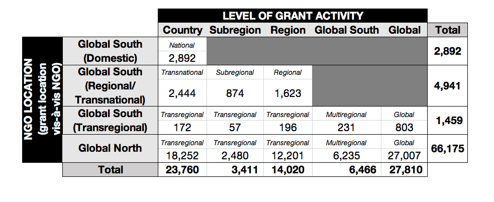

## Variable Recoding

Looking at Private Foundations (PF) and Public Charities (PC) and how they compare to Grantmaker Type:

```r
dat %>%
  group_by( LEVEL1, GM_TYPE ) %>%
  summarize( n = n(),
             percentage = n / nrow( dat ) ) %>%
  kable( digits = 2 )
```

| LEVEL1 | GM_TYPE | n | percentage |
| --- | --- | --- | --- |
| PC | CM | 11006 | 0.12 |
| PC | CS | 1291 | 0.01 |
| PC | IN | 11186 | 0.12 |
| PC | OP | 1109 | 0.01 |
| PF | CS | 15621 | 0.16 |
| PF | IN | 50771 | 0.53 |
| PF | OP | 1798 | 0.02 |
| NA | CM | 433 | 0.00 |
| NA | CS | 33 | 0.00 |
| NA | IN | 2241 | 0.02 |
| NA | OP | 17 | 0.00 |

```r
dat$LEVEL1[ dat$GM_TYPE == "CM" ] <- "PC"
```

```r
# region by program area interaction

dat$REGION_BY_SECTOR[ is.na( dat$GRANT_REGION_IMPUTED ) ] <- NA
dat$REGION_BY_SECTOR[ is.na( dat$PRIMARY_CODE_DESC ) ] <- NA

t1 <- table( dat$REGION_BY_SECTOR, useNA="ifany" )

# drop groups with less than 10 observations

dat$REGION_BY_SECTOR[ dat$REGION_BY_SECTOR %in% names( t1 )[ t1 < 10 ] ] <- NA

dat$REPEAT <- as.numeric( dat$STATUS == "RENEW" )

dat$PROP_FGRANTS_INT[ dat$PROP_FGRANTS_INT < 0 ] <- 0
dat$PROP_FGRANTS_INT[ dat$PROP_FGRANTS_INT > 1 ] <- 1
```

# MODELS

First replicating the old models with the added geographic regions and the addition of foundation type.

```r
dat$LOG_F_ASSETS_SQUARED <- dat$LOG_F_ASSETS^2
dat$LOG_F_REGION_EXPERIENCE <- log( dat$F_REGION_EXPERIENCE + 1 )
dat$LOG_F_SECTOR_EXPERIENCE <- log( dat$F_SECTOR_EXPERIENCE + 1 )
dat$LOG_F_COUNTRY_EXPERIENCE <- log( dat$F_COUNTRY_EXPERIENCE + 1 )
dat$REGION_BY_SECTOR <- factor( dat$REGION_BY_SECTOR )
dat$PRIMARY_CODE_DESC <- factor( dat$PRIMARY_CODE_DESC )
dat$YR_ISSUED <- factor( dat$YR_ISSUED )

d4 <- dat[ !is.na( dat$LEVEL1 != "PC" ), ]


# ASIA
d.asia <- d4[  d4$GRANT_REGION_IMPUTED %in% c( "Asia" ) , ]
d.asia$ASIA_DUMMY <- as.numeric( d.asia$NGO_REGION == "Asia" )
d.asia$ASIA_DUMMY[ is.na( d.asia$ASIA_DUMMY ) ] <- 0
d.asia <- d.asia %>%
  group_by( GM_KEY ) %>%
  mutate( PROP_FGRANTS_REGION = mean( FOREIGN_DUMMY ) ) %>%
  ungroup()
d.asia$DV <- d.asia$ASIA_DUMMY

# AFRICA
d.africa <- d4[  d4$GRANT_REGION_IMPUTED %in% c( "Africa" ) , ]
d.africa$AFRICA_DUMMY <- as.numeric( d.africa$NGO_REGION == "Africa" )
d.africa$AFRICA_DUMMY[ is.na( d.africa$AFRICA_DUMMY ) ] <- 0
d.africa <- d.africa %>%
  group_by( GM_KEY ) %>%
  mutate( PROP_FGRANTS_REGION = mean( FOREIGN_DUMMY ) ) %>%
  ungroup()
d.africa$DV <- d.africa$AFRICA_DUMMY

# LATIN AMERICA
d.latin.america <- d4[  d4$GRANT_REGION_IMPUTED %in% c( "Latin America" ), ]
d.latin.america$LATIN_AMERICA_DUMMY <- as.numeric( d.latin.america$NGO_REGION ==
                                                     "Latin America" )
d.latin.america$LATIN_AMERICA_DUMMY[ d.latin.america$LATIN_AMERICA_DUMMY ] <- 0
d.latin.america <- d.latin.america %>%
  group_by( GM_KEY ) %>%
  mutate( PROP_FGRANTS_REGION = mean( FOREIGN_DUMMY ) ) %>%
  ungroup()
d.latin.america$DV <- d.latin.america$LATIN_AMERICA_DUMMY

# FORMER USSR
d.ussr <- d4[ d4$GRANT_REGION_IMPUTED %in% c( "Former USSR" ), ]
d.ussr$USSR_DUMMY <- as.numeric( d.ussr$NGO_REGION == "Former USSR" )
d.ussr$USSR_DUMMY[ d.ussr$USSR_DUMMY ] <- 0
d.ussr <- d.ussr %>%
  group_by( GM_KEY ) %>%
  mutate( PROP_FGRANTS_REGION = mean( FOREIGN_DUMMY ) ) %>%
  ungroup()
d.ussr$DV <- d.ussr$USSR_DUMMY

# MIDDLE EAST
d.middle.east <- d4[  d4$GRANT_REGION_IMPUTED %in% c( "Middle East" ) &
                        !is.na( d4$GRANT_REGION ), ]
d.middle.east$MIDDLE_EAST_DUMMY <- as.numeric( d.middle.east$NGO_REGION ==
                                                 "Middle East" )
d.middle.east$MIDDLE_EAST_DUMMY[ is.na( d.middle.east$MIDDLE_EAST_DUMMY ) ] <- 0
d.middle.east <- d.middle.east %>%
  group_by( GM_KEY ) %>%
  mutate( PROP_FGRANTS_REGION = mean( FOREIGN_DUMMY ) ) %>%
  ungroup()
d.middle.east$DV <- d.middle.east$MIDDLE_EAST_DUMMY

# Israel
d.israel <- d4[ d4$GRANT_REGION_IMPUTED %in% c( "Israel" ), ]
d.israel$ISRAEL_DUMMY <- as.numeric( d.israel$Country == "Israel" )
d.israel$ISRAEL_DUMMY[ is.na( d.israel$ISRAEL_DUMMY ) ] <- 0
d.israel <- d.israel %>%
  group_by( GM_KEY ) %>%
  mutate( PROP_FGRANTS_REGION = mean( FOREIGN_DUMMY ) ) %>%
  ungroup()
d.israel$DV <- d.israel$ISRAEL_DUMMY


prop.local <- c( mean( d.asia$ASIA_DUMMY ),
                 mean( d.africa$AFRICA_DUMMY ),
                 mean( d.latin.america$LATIN_AMERICA_DUMMY ),
                 mean( d.ussr$USSR_DUMMY ),
                 mean( d.middle.east$MIDDLE_EAST_DUMMY ),
                 mean( d.israel$ISRAEL_DUMMY ) ) %>%
  round(2)


### REGIONS

mod.formula <- DV ~ FAGE + LOG_F_ASSETS + LOG_F_ASSETS_SQUARED + I( LEVEL1 == "PC" ) +
                    LOG_F_REGION_EXPERIENCE + LOG_F_SECTOR_EXPERIENCE +
                    LOG_AMOUNT + DURATION +
                    PROP_FGRANTS_REGION + PROP_FGRANTS_INT +
                    PRIMARY_CODE_DESC

m.203 <- lm( mod.formula, data = d.asia )
m.204 <- lm( mod.formula, data = d.africa )
m.205 <- lm( mod.formula, data = d.latin.america )
m.206 <- lm( mod.formula, data = d.ussr )
m.207 <- lm( mod.formula, data = d.middle.east )
m.208 <- lm( mod.formula, data = d.israel )


stargazer( m.203, m.204, m.205, m.206, m.207, m.208,
           dep.var.labels.include = FALSE,
           dep.var.caption = "DV: Grant Recipient is Local [1,0]",
           column.labels = c( "Asia", "Africa", "Latin America", "Former USSR",
                              "Middle East", "Israel" ),
           omit.stat = c( "rsq", "f", "ser" ),
           omit = c( "GM_KEY", "REGION_BY_SECTOR", "GRANT_REGION_IMPUTED",
                     "PRIMARY_CODE_DESC" ),
           add.lines = list( c( "DV: Proportion Local", prop.local ),
                             c("Program Area Fixed Effects?", "Yes", "Yes",
                               "Yes", "Yes", "Yes", "Yes" ) ),
           covariate.labels = c( "Foundation Age", "Foundation Size (log of assets)",
                                 "Foundation Size Squared",
                                 "Public Charity", "Foundation Regional Experience",
                                 "Foundation Program Area Experience",
                                 "Grant Size (log of amount)", "Grant Length",
                                 "Prop Grants to Foreign NGOs", "Prop. of Grants Int.",
                                 "Intercept"),
           digits = 2, type = "html" )
```

|  | DV: Grant Recipient is Local [1,0] |  |  |  |  |  |
| --- | --- | --- | --- | --- | --- | --- |
|  | Asia | Africa | Latin America | Former USSR | Middle East | Israel |
|  | (1) | (2) | (3) | (4) | (5) | (6) |
| Foundation Age | 0.0005*** | 0.001*** | -0.0000 | -0.0003 | -0.0000 | 0.0001 |
|  | (0.0001) | (0.0001) | (0.0001) | (0.0002) | (0.0003) | (0.0001) |
| Foundation Size (log of assets) | 0.03*** | 0.01*** | -0.001 | 0.001 | 0.01 | 0.03*** |
|  | (0.01) | (0.01) | (0.01) | (0.01) | (0.01) | (0.01) |
| Foundation Size Squared | -0.001*** | -0.001*** | -0.0001 | -0.0001 | -0.001 | -0.001*** |
|  | (0.0002) | (0.0002) | (0.0004) | (0.0003) | (0.0004) | (0.0002) |
| Public Charity | -0.004 | -0.02** | -0.01 | 0.01 | -0.02 | 0.01 |
|  | (0.01) | (0.01) | (0.01) | (0.01) | (0.02) | (0.01) |
| Foundation Regional Experience | -0.01** | 0.01** | -0.003 | 0.01 | 0.003 | 0.001 |
|  | (0.003) | (0.004) | (0.003) | (0.01) | (0.01) | (0.002) |
| Foundation Program Area Experience | 0.02*** | 0.01*** | 0.01*** | 0.02*** | -0.002 | 0.005** |
|  | (0.003) | (0.003) | (0.003) | (0.01) | (0.01) | (0.002) |
| Grant Size (log of amount) | -0.01*** | -0.01*** | -0.003 | -0.01*** | -0.01 | 0.01*** |
|  | (0.002) | (0.003) | (0.003) | (0.005) | (0.01) | (0.001) |
| Grant Length | 0.03*** | 0.01** | 0.004 | 0.03*** | 0.002 | 0.001 |
|  | (0.004) | (0.004) | (0.01) | (0.01) | (0.01) | (0.01) |
| Prop Grants to Foreign NGOs | 0.87*** | 0.81*** | 0.89*** | 0.81*** | 0.62*** | 0.68*** |
|  | (0.01) | (0.01) | (0.01) | (0.02) | (0.03) | (0.03) |
| Prop. of Grants Int. | -0.02 | -0.08*** | -0.03* | 0.02 | -0.02 | 0.01 |
|  | (0.01) | (0.02) | (0.02) | (0.03) | (0.04) | (0.01) |
| Intercept | -0.07 | 0.10 | 0.08 | 0.08 | 0.04 | -0.28*** |
|  | (0.08) | (0.06) | (0.14) | (0.11) | (0.15) | (0.06) |
| DV: Proportion Local | 0.45 | 0.41 | 0.4 | 0.46 | 0.1 | 0.02 |
| Program Area Fixed Effects? | Yes | Yes | Yes | Yes | Yes | Yes |
| Observations | 14,279 | 12,834 | 13,075 | 3,717 | 1,614 | 5,561 |
| Adjusted R<sup>2</sup> | 0.61 | 0.49 | 0.51 | 0.57 | 0.34 | 0.18 |
| *Note:* | p<0.1; p<0.05; p<0.01 |  |  |  |  |  |

## Controlling for Country

Several things I wanted to experiment here.

### Country Experience

First, I created a “Country Experience” variable exactly how we did region experience, just by country instead of region. This may be a more fine-grained sense of experience. It’s correlatoin with region experience is 0.71, quite high, but not as high as I might have expected.

```r
mod.formula <- DV ~ FAGE + LOG_F_ASSETS + LOG_F_ASSETS_SQUARED + I( LEVEL1 == "PC" ) +
                    LOG_F_COUNTRY_EXPERIENCE + LOG_F_SECTOR_EXPERIENCE +
                    LOG_AMOUNT + DURATION +
                    PROP_FGRANTS_REGION + PROP_FGRANTS_INT +
                    PRIMARY_CODE_DESC

m.203 <- lm( mod.formula, data = d.asia )
m.204 <- lm( mod.formula, data = d.africa )
m.205 <- lm( mod.formula, data = d.latin.america )
m.206 <- lm( mod.formula, data = d.ussr )
m.207 <- lm( mod.formula, data = d.middle.east )
m.208 <- lm( mod.formula, data = d.israel )


stargazer( m.203, m.204, m.205, m.206, m.207, m.208,
           dep.var.labels.include = FALSE,
           dep.var.caption = "DV: Grant Recipient is Local [1,0]",
           column.labels = c( "Asia", "Africa", "Latin America", "Former USSR",
                              "Middle East", "Israel" ),
           omit.stat = c( "rsq", "f", "ser" ),
           omit = c( "GM_KEY", "REGION_BY_SECTOR", "GRANT_REGION_IMPUTED",
                     "PRIMARY_CODE_DESC" ),
           add.lines = list( c( "DV: Proportion Local", prop.local ),
                             c("Program Area Fixed Effects?", "Yes", "Yes",
                               "Yes", "Yes", "Yes", "Yes" ) ),
           covariate.labels = c( "Foundation Age", "Foundation Size (log of assets)",
                                 "Foundation Size Squared",
                                 "Public Charity", "Foundation Country Experience",
                                 "Foundation Program Area Experience",
                                 "Grant Size (log of amount)", "Grant Length",
                                 "Prop Grants to Foreign NGOs", "Prop. of Grants Int.",
                                 "Intercept"),
           digits = 2, type = "html" )
```

|  | DV: Grant Recipient is Local [1,0] |  |  |  |  |  |
| --- | --- | --- | --- | --- | --- | --- |
|  | Asia | Africa | Latin America | Former USSR | Middle East | Israel |
|  | (1) | (2) | (3) | (4) | (5) | (6) |
| Foundation Age | 0.001*** | 0.001*** | 0.001*** | -0.0004 | 0.0001 | 0.0001 |
|  | (0.0001) | (0.0001) | (0.0001) | (0.0003) | (0.0003) | (0.0001) |
| Foundation Size (log of assets) | 0.001 | -0.02** | -0.001 | -0.003 | 0.01 | 0.03*** |
|  | (0.01) | (0.01) | (0.01) | (0.01) | (0.01) | (0.01) |
| Foundation Size Squared | -0.0001 | 0.0005** | 0.0003 | 0.0000 | -0.001 | -0.001*** |
|  | (0.0003) | (0.0002) | (0.0004) | (0.0004) | (0.0004) | (0.0002) |
| Public Charity | -0.02*** | -0.05*** | -0.07*** | -0.03* | -0.05*** | 0.01 |
|  | (0.01) | (0.01) | (0.01) | (0.02) | (0.02) | (0.01) |
| Foundation Country Experience | 0.01*** | 0.01*** | 0.03*** | -0.003 | -0.03*** | 0.001 |
|  | (0.003) | (0.003) | (0.003) | (0.01) | (0.01) | (0.002) |
| Foundation Program Area Experience | 0.002 | 0.003 | -0.01*** | 0.01 | 0.01* | 0.005** |
|  | (0.003) | (0.003) | (0.003) | (0.01) | (0.01) | (0.002) |
| Grant Size (log of amount) | 0.001 | 0.001 | 0.01*** | 0.01** | -0.01* | 0.01*** |
|  | (0.003) | (0.003) | (0.003) | (0.01) | (0.01) | (0.001) |
| Grant Length | 0.02*** | 0.002 | 0.03*** | 0.05*** | 0.002 | 0.001 |
|  | (0.01) | (0.004) | (0.01) | (0.01) | (0.01) | (0.01) |
| Prop Grants to Foreign NGOs | 0.43*** | 0.40*** | 0.45*** | 0.42*** | 0.64*** | 0.68*** |
|  | (0.01) | (0.01) | (0.01) | (0.02) | (0.03) | (0.03) |
| Prop. of Grants Int. | 0.02 | -0.03** | -0.01 | 0.01 | 0.01 | 0.01 |
|  | (0.02) | (0.02) | (0.02) | (0.04) | (0.04) | (0.01) |
| Intercept | -0.10 | 0.09 | -0.27* | -0.12 | 0.05 | -0.28*** |
|  | (0.10) | (0.08) | (0.14) | (0.13) | (0.15) | (0.06) |
| DV: Proportion Local | 0.45 | 0.41 | 0.4 | 0.46 | 0.1 | 0.02 |
| Program Area Fixed Effects? | Yes | Yes | Yes | Yes | Yes | Yes |
| Observations | 8,924 | 9,003 | 9,201 | 2,344 | 1,614 | 5,561 |
| Adjusted R<sup>2</sup> | 0.27 | 0.26 | 0.33 | 0.28 | 0.35 | 0.18 |
| *Note:* | p<0.1; p<0.05; p<0.01 |  |  |  |  |  |

### Controlling for Country

I then wondered what would happen if we included country fixed effects. This may help us run something more similar to the domestic models below. Although this has the same problem as above by having to throw out all the imputed grants.

```r
mod.formula <- DV ~ FAGE + LOG_F_ASSETS + LOG_F_ASSETS_SQUARED + I( LEVEL1 == "PC" ) +
                    LOG_F_REGION_EXPERIENCE + LOG_F_SECTOR_EXPERIENCE +
                    LOG_AMOUNT + DURATION +
                    PROP_FGRANTS_REGION + PROP_FGRANTS_INT +
                    PRIMARY_CODE_DESC + GRANT_COUNTRY

d.africa2 <- d.africa
d.africa2$GRANT_COUNTRY <- as.character( d.africa2$GRANT_COUNTRY )
d.africa2$GRANT_COUNTRY[ as.character( d.africa2$GRANT_COUNTRY ) ==
                          "C\x93te d'Ivoire" ] <- "Cote D'Ivoire"
d.africa2$GRANT_COUNTRY <- factor( d.africa2$GRANT_COUNTRY )

m.203 <- lm( mod.formula, data = d.asia )
m.204 <- lm( mod.formula, data = d.africa2 )
m.205 <- lm( mod.formula, data = d.latin.america )
m.206 <- lm( mod.formula, data = d.ussr )
m.207 <- lm( mod.formula, data = d.middle.east )

mod.formula <- DV ~ FAGE + LOG_F_ASSETS + LOG_F_ASSETS_SQUARED + I( LEVEL1 == "PC" ) +
                    LOG_F_REGION_EXPERIENCE + LOG_F_SECTOR_EXPERIENCE +
                    LOG_AMOUNT + DURATION +
                    PROP_FGRANTS_REGION + PROP_FGRANTS_INT +
                    PRIMARY_CODE_DESC

m.208 <- lm( mod.formula, data = d.israel )


stargazer( m.203, m.204, m.205, m.206, m.207, m.208,
           dep.var.labels.include = FALSE,
           dep.var.caption = "DV: Grant Recipient is Local [1,0]",
           column.labels = c( "Asia", "Africa", "Latin America", "Former USSR",
                              "Middle East", "Israel" ),
           omit.stat = c( "rsq", "f", "ser" ),
           omit = c( "GM_KEY", "REGION_BY_SECTOR", "GRANT_REGION_IMPUTED",
                     "PRIMARY_CODE_DESC", "GRANT_COUNTRY" ),
           add.lines = list( c( "DV: Proportion Local", prop.local ),
                             c( "Program Area Fixed Effects?", "Yes", "Yes",
                               "Yes", "Yes", "Yes", "Yes" ),
                             c( "Country Fixed Effects?", "Yes", "Yes",
                               "Yes", "Yes", "Yes", "N/A" ) ),
           covariate.labels = c( "Foundation Age", "Foundation Size (log of assets)",
                                 "Foundation Size Squared",
                                 "Public Charity", "Foundation Region Experience",
                                 "Foundation Program Area Experience",
                                 "Grant Size (log of amount)", "Grant Length",
                                 "Prop Grants to Foreign NGOs", "Prop. of Grants Int.",
                                 "Intercept"),
           digits = 2, type = "html" )
```

|  | DV: Grant Recipient is Local [1,0] |  |  |  |  |  |
| --- | --- | --- | --- | --- | --- | --- |
|  | Asia | Africa | Latin America | Former USSR | Middle East | Israel |
|  | (1) | (2) | (3) | (4) | (5) | (6) |
| Foundation Age | 0.001*** | 0.001*** | 0.001*** | -0.0001 | -0.0000 | 0.0001 |
|  | (0.0001) | (0.0001) | (0.0001) | (0.0003) | (0.0003) | (0.0001) |
| Foundation Size (log of assets) | 0.002 | -0.02** | -0.004 | -0.004 | 0.02 | 0.03*** |
|  | (0.01) | (0.01) | (0.01) | (0.01) | (0.01) | (0.01) |
| Foundation Size Squared | -0.0001 | 0.0004** | 0.0004 | 0.0002 | -0.001** | -0.001*** |
|  | (0.0003) | (0.0002) | (0.0004) | (0.0004) | (0.0004) | (0.0002) |
| Public Charity | -0.04*** | -0.06*** | -0.07*** | -0.04** | -0.02 | 0.01 |
|  | (0.01) | (0.01) | (0.01) | (0.02) | (0.02) | (0.01) |
| Foundation Region Experience | -0.003 | 0.001 | 0.01*** | 0.01** | 0.002 | 0.001 |
|  | (0.003) | (0.004) | (0.003) | (0.01) | (0.01) | (0.002) |
| Foundation Program Area Experience | 0.01*** | 0.01** | -0.01* | -0.004 | 0.001 | 0.005** |
|  | (0.003) | (0.004) | (0.003) | (0.01) | (0.01) | (0.002) |
| Grant Size (log of amount) | -0.001 | 0.002 | 0.01* | 0.01 | -0.01 | 0.01*** |
|  | (0.003) | (0.003) | (0.003) | (0.01) | (0.01) | (0.001) |
| Grant Length | 0.02*** | -0.001 | 0.03*** | 0.06*** | 0.001 | 0.001 |
|  | (0.01) | (0.004) | (0.01) | (0.01) | (0.01) | (0.01) |
| Prop Grants to Foreign NGOs | 0.43*** | 0.39*** | 0.41*** | 0.43*** | 0.59*** | 0.68*** |
|  | (0.01) | (0.01) | (0.01) | (0.02) | (0.03) | (0.03) |
| Prop. of Grants Int. | 0.03* | -0.03 | -0.02 | -0.03 | -0.04 | 0.01 |
|  | (0.02) | (0.02) | (0.02) | (0.04) | (0.04) | (0.01) |
| Intercept | -0.12 | 0.10 | 0.55* | -0.20 | -0.02 | -0.28*** |
|  | (0.10) | (0.08) | (0.33) | (0.14) | (0.15) | (0.06) |
| DV: Proportion Local | 0.45 | 0.41 | 0.4 | 0.46 | 0.1 | 0.02 |
| Program Area Fixed Effects? | Yes | Yes | Yes | Yes | Yes | Yes |
| Country Fixed Effects? | Yes | Yes | Yes | Yes | Yes | N/A |
| Observations | 8,924 | 9,003 | 9,201 | 2,344 | 1,614 | 5,561 |
| Adjusted R<sup>2</sup> | 0.28 | 0.28 | 0.35 | 0.33 | 0.38 | 0.18 |
| *Note:* | p<0.1; p<0.05; p<0.01 |  |  |  |  |  |

We can’t control for region in the region-specific models. But we can control for region if we group all of our regions together. We can also control for region as we look at our domestic dummies.

```r
d.globalsouth <- dat[ dat$GRANT_REGION_IMPUTED %in% global_south_regions, ]
d.dom <- d.globalsouth[ !is.na( d.globalsouth$GRANT_COUNTRY ), ]
d.globalsouth$DV <- as.numeric( d.globalsouth$DOMESTIC_DUMMY == 1 |
                                  d.globalsouth$REGIONAL_DUMMY == 1 )

d.dom <- d.dom %>%
  group_by( GM_KEY ) %>%
  mutate( PROP_FGRANTS_REGION = mean( FOREIGN_DUMMY ) ) %>%
  ungroup()

d.globalsouth <- d.globalsouth %>%
  group_by( GM_KEY ) %>%
  mutate( PROP_FGRANTS_REGION = mean( FOREIGN_DUMMY ) ) %>%
  ungroup()

mod.formula <- DV ~ FAGE + LOG_F_ASSETS + LOG_F_ASSETS_SQUARED +
  I( LEVEL1 == "PC" ) + LOG_F_REGION_EXPERIENCE + LOG_F_SECTOR_EXPERIENCE + LOG_AMOUNT +
  DURATION + PROP_FGRANTS_REGION + PROP_FGRANTS_INT + REGION_BY_SECTOR

m.all <- lm( mod.formula, data = d.globalsouth )

mod.formula <- DOMESTIC_DUMMY ~ FAGE + LOG_F_ASSETS + LOG_F_ASSETS_SQUARED +
  I( LEVEL1 == "PC" ) + LOG_F_REGION_EXPERIENCE + LOG_F_SECTOR_EXPERIENCE + LOG_AMOUNT +
  DURATION + PROP_FGRANTS_REGION + PROP_FGRANTS_INT + REGION_BY_SECTOR

m.dom <- lm( mod.formula, data = d.dom )

stargazer( m.all, m.dom,
           dep.var.labels.include = FALSE,
           column.labels = c( "DV: Regional", "DV: Domestic" ),
           omit.stat = c( "rsq", "f", "ser" ),
           omit = c( "REGION_BY_SECTOR" ),
           add.lines = list( c( "Program Area Fixed Effects?", "Yes", "Yes" ),
                             c( "Region Fixed Effects?", "Yes", "Yes" ) ),
           covariate.labels = c( "Foundation Age", "Foundation Size (log of assets)",
                                 "Foundation Size Squared",
                                 "Public Charity", "Foundation Region Experience",
                                 "Foundation Program Area Experience",
                                 "Grant Size (log of amount)", "Grant Length",
                                 "Prop Grants to Foreign NGOs", "Prop. of Grants Int.",
                                 "Intercept"),
           digits = 2, type = "html" )
```

|  | *Dependent variable:* |  |
| --- | --- | --- |
|  | DV: Regional | DV: Domestic |
|  | (1) | (2) |
| Foundation Age | 0.0003*** | 0.0001** |
|  | (0.0001) | (0.0001) |
| Foundation Size (log of assets) | 0.02*** | 0.03*** |
|  | (0.004) | (0.003) |
| Foundation Size Squared | -0.001*** | -0.001*** |
|  | (0.0001) | (0.0001) |
| Public Charity | -0.01** | -0.01*** |
|  | (0.004) | (0.003) |
| Foundation Region Experience | 0.01*** | 0.002* |
|  | (0.002) | (0.001) |
| Foundation Program Area Experience | 0.01*** | -0.003** |
|  | (0.002) | (0.001) |
| Grant Size (log of amount) | -0.01*** | 0.0002 |
|  | (0.001) | (0.001) |
| Grant Length | 0.01*** | 0.01*** |
|  | (0.002) | (0.002) |
| Prop Grants to Foreign NGOs | 0.84*** | 0.36*** |
|  | (0.01) | (0.01) |
| Prop. of Grants Int. | -0.05*** | -0.02*** |
|  | (0.01) | (0.01) |
| Intercept | -0.06 | -0.19*** |
|  | (0.04) | (0.03) |
| Program Area Fixed Effects? | Yes | Yes |
| Region Fixed Effects? | Yes | Yes |
| Observations | 52,654 | 36,648 |
| Adjusted R<sup>2</sup> | 0.52 | 0.15 |
| *Note:* | p<0.1; p<0.05; p<0.01 |  |

The data set here are all the grants given to the global south. I accidentally didn’t do that first and got some fascinating results that made me want to explore what’s happening in the global north.

So this next model is the exact same model but for grants that are targeted to Europe or North America:

```r
global_north_regions <- c( "Europe", "Northern America" )

d.globalnorth <- dat[ dat$GRANT_REGION_IMPUTED %in% global_north_regions, ]
d.dom <- d.globalnorth[ !is.na( d.globalnorth$GRANT_COUNTRY ), ]
d.globalnorth$DV <- as.numeric( d.globalnorth$DOMESTIC_DUMMY == 1 |
                                  d.globalnorth$REGIONAL_DUMMY == 1 )

d.dom <- d.dom %>%
  group_by( GM_KEY ) %>%
  mutate( PROP_FGRANTS_REGION = mean( FOREIGN_DUMMY ) ) %>%
  ungroup()

d.globalnorth <- d.globalnorth %>%
  group_by( GM_KEY ) %>%
  mutate( PROP_FGRANTS_REGION = mean( FOREIGN_DUMMY ) ) %>%
  ungroup()

mod.formula <- DV ~ FAGE + LOG_F_ASSETS + LOG_F_ASSETS_SQUARED +
  I( LEVEL1 == "PC" ) + LOG_F_REGION_EXPERIENCE + LOG_F_SECTOR_EXPERIENCE + LOG_AMOUNT +
  DURATION + PROP_FGRANTS_REGION + PROP_FGRANTS_INT + REGION_BY_SECTOR

m.all <- lm( mod.formula, data = d.globalnorth )

mod.formula <- DOMESTIC_DUMMY ~ FAGE + LOG_F_ASSETS + LOG_F_ASSETS_SQUARED +
  I( LEVEL1 == "PC" ) + LOG_F_REGION_EXPERIENCE + LOG_F_SECTOR_EXPERIENCE + LOG_AMOUNT +
  DURATION + PROP_FGRANTS_REGION + PROP_FGRANTS_INT + REGION_BY_SECTOR

m.dom <- lm( mod.formula, data = d.dom )

stargazer( m.all, m.dom,
           dep.var.labels.include = FALSE,
           column.labels = c( "DV: Regional", "DV: Domestic" ),
           omit.stat = c( "rsq", "f", "ser" ),
           omit = c( "REGION_BY_SECTOR" ),
           add.lines = list( c( "Program Area Fixed Effects?", "Yes", "Yes" ),
                             c( "Region Fixed Effects?", "Yes", "Yes" ) ),
           covariate.labels = c( "Foundation Age", "Foundation Size (log of assets)",
                                 "Foundation Size Squared",
                                 "Public Charity", "Foundation Region Experience",
                                 "Foundation Program Area Experience",
                                 "Grant Size (log of amount)", "Grant Length",
                                 "Prop Grants to Foreign NGOs", "Prop. of Grants Int.",
                                 "Intercept"),
           digits = 2, type = "html" )
```

[output not shown]

Here there isn’t as much significant due to the small number of grants, but what is strong and impressive is the program experience is negatively related to regional grantmaking and positively related to domestic grantmaking, the exact opposite of what we saw in the global south regions. This to me is a simpler, stronger, and more fascinating phenomenon than the previous focus in the PAR paper. I think we can still use the past models to give more color to what we see in these two models, but there is something fascinating here that seems that it belongs in the same story that we’re trying to tell.

So what does this mean? Here’s a brain dump and an idea:

When US foundations give to their compatriots in the global north, targeted grants to specific NGOs in specific countries, the foundations don’t rely on their experience in the region, but they do rely on their program experience. The more program experience they have the more likely they’ll make these “targeted” grants. However, when they don’t have program experience they’ll just give to the region. But this is different from region experience which either doesn’t matter in the case of the region, or is negatively related to making these “targeted” grants. Maybe there’s a story here of specialists and professionals in the global north. With globalization, those in the north are highly mobile and run in program-specialized circles not regionally specific circles. However, these specialists themselves, are still locally based and will advocate for grants to go to their home country. In other words, these grant-getters run in two social circles, the geographically unbound program-specific circle, and the highly local bound country where they live.

This is different from the global south where program area experienec looks the opposite. In the global south the specialists and professionals are less likely to be indigenous, thus they lack the second social circle of a national country. Instead, it is likely that they do run in a second social circle, but this time it’s a region-specific one. These professionals adopt the “identity” of the region they’re in; don’t stay in the same country but bounce around not building loyalty in any one country. Thus, when a foundation has high program experience it gives to these professionals who are regionally, not domestically oriented. Because of these social circles and this lack of loyalty, both region and program experience relate to regional giving. Program experience would actually discount giving to a domestic program, so foundations that have program experience are less likely to do so. Regional experience would be fairly necessary to make these domestic grants (just to here about the organizations), but because those who are regional experts are these regional professionals, they will push for regional-level grants. Thus, while region experience is important, it is severly attenuated.

To check this hypothesis, I’d probably want to gather data on something like college education rates as a proxy for percentage of indigenous NGO staff. We can see if including that as a control would clear these effects of experience.